# RNA-seq analysis in R

Gene Set Testing for RNA-seq

Stephane Ballereau, Mark Dunning, Oscar Rueda, Ashley Sawle

Last modified: 14 Jun 2018

This material has been created using the following resources:  
http://www.statsci.org/smyth/pubs/QLedgeRPreprint.pdf (Lun, Chen, and Smyth 2016)  
https://github.com/MonashBioinformaticsPlatform/RNAseq-DE-analysis-with-R

Data files:  
https://figshare.com/s/1d788fd384d33e913a2a : mouse_c2_v5.rdata mouse_H_v5.rdata

# Gene Set Testing

The list of differentially expressed genes is sometimes so long that its interpretation becomes cumbersome and time consuming. A common downstream procedure is gene set testing. It aims to understand which pathways or gene networks the differentially expressed genes are implicated in.

Various ways exist to test for enrichment of biological pathways. Two types of test answer two different questions: competitive and self-contained gene set tests.

Competitive gene set tests, such as those implemented in `GOseq` and `camera`, ask the question whether the differentially expressed genes tend to be over-represented in the gene set, compared to all the other genes in the experiment.

Self-contained tests, which include the `ROAST` procedure, ask the question “Are the genes in the set/pathway differentially expressed as a whole?”

```r
load("Robjects/DE.Rdata")
```

## Gene Set Testing - competitive gene set tests

### GOseq analysis

GOseq is a method to conduct Gene Ontology (GO) analysis suitable for RNA-seq data as it accounts for the gene length bias in detection of over-representation ([GOseq article](https://genomebiology.biomedcentral.com/articles/10.1186/gb-2010-11-2-r14))

From the [GOseq vignette](https://www.bioconductor.org/packages/release/bioc/vignettes/goseq/inst/doc/goseq.pdf):

- GOseq first needs to quantify the length bias present in the dataset under consideration.
- This is done by calculating a Probability Weighting Function or PWF which can be thought of as a function which gives the probability that a gene will be differentially expressed (DE), based on its length alone.
- The PWF is calculated by fitting a monotonic spline to the binary data series of differential expression (1=DE, 0=Not DE) as a function of gene length.
- The PWF is used to weight the chance of selecting each gene when forming a null distribution for GO category membership.
- The fact that the PWF is calculated directly from the dataset under consideration makes this approach robust, only correcting for the length bias present in the data.

“GO analysis of RNA-seq data requires the use of random sampling in order to generate a suitable null distribution for GO category membership and calculate each category’s significance for over representation amongst DE genes. … In most cases, the Wallenius distribution can be used to approximate the true null distribution, without any significant loss in accuracy. The goseq package implements this approximation as its default option.”

Create list of DEGs:

```r
# Retrieve list of all genes tested:
results <- as.data.frame(topTags(lrt_BvsL, n = Inf))
print(head(results))
```

```
           logFC    logCPM       LR       PValue          FDR
110308 -8.940579 10.264297 24.89789 6.044844e-07 0.0004377961
50916  -8.636503  5.749781 24.80037 6.358512e-07 0.0004377961
12293  -8.362247  6.794788 24.68526 6.749827e-07 0.0004377961
56069  -8.419433  6.124377 24.41532 7.764861e-07 0.0004377961
24117  -9.290691  6.757163 24.32506 8.137331e-07 0.0004377961
12818  -8.216790  8.172247 24.24233 8.494462e-07 0.0004377961
```

```r
# Derive list of DEGs by filtering on FDR:
genes <- results$FDR < 0.01
# Add gene names to that list:
names(genes) <- rownames(results)
print(head(genes))
```

```
110308  50916  12293  56069  24117  12818
  TRUE   TRUE   TRUE   TRUE   TRUE   TRUE
```

```r
library(goseq)
#print(supportedGeneIDs())
#print(supportedGenomes())
```

Fit the Probability Weighting Function (PWF):

```
Can't find mm10/knownGene length data in genLenDataBase...
Found the annotaion package, TxDb.Mmusculus.UCSC.mm10.knownGene
Trying to get the gene lengths from it.
initial point very close to some inequality constraints
```

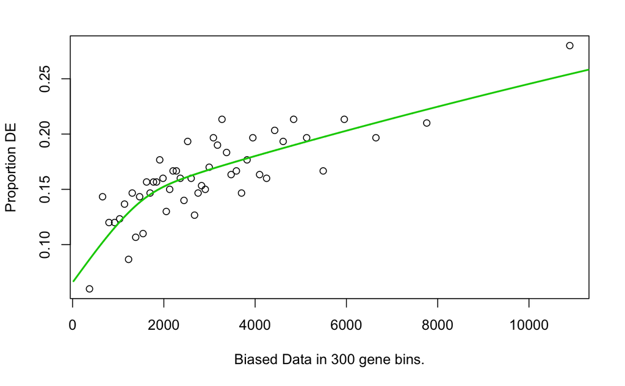

```r
pwf <- nullp(genes, "mm10","knownGene")
```

Conduct gene set enrichment analysis:

```r
#?goseq
go.results <- goseq(pwf, "mm10","knownGene")
```

```
Fetching GO annotations...
For 1098 genes, we could not find any categories. These genes will be excluded.
To force their use, please run with use_genes_without_cat=TRUE (see documentation).
This was the default behavior for version 1.15.1 and earlier.
Calculating the p-values...
```

```r
go.results
```

```
        category over_represented_pvalue under_represented_pvalue numDEInCat numInCat
16050 GO:0071944            1.309860e-60             1.000000e+00        914     3479
2732  GO:0005886            3.047483e-60             1.000000e+00        891     3366
2546  GO:0005576            6.173175e-59             1.000000e+00        455     1407
11217 GO:0044421            8.851266e-53             1.000000e+00        377     1113
2570  GO:0005615            6.569087e-46             1.000000e+00        310      902
11247 GO:0044459            1.032989e-43             1.000000e+00        528     1816
7495  GO:0031224            3.155148e-43             1.000000e+00        834     3412
5495  GO:0016021            1.485398e-38             1.000000e+00        798     3303
8198  GO:0032501            1.811444e-37             1.000000e+00       1102     4932
4443  GO:0009653            4.827762e-36             1.000000e+00        571     2110
11220 GO:0044425            1.640138e-35             1.000000e+00        985     4395
7497  GO:0031226            5.474171e-35             1.000000e+00        303      913
2733  GO:0005887            4.553690e-34             1.000000e+00        288      856
12742 GO:0048731            1.704637e-33             1.000000e+00        827     3480
```

[output cut: 415 more lines]

### fgsea analysis

From the fgsea [vignette](http://www.bioconductor.org/packages/release/bioc/vignettes/fgsea/inst/doc/fgsea-tutorial.html) “fast preranked gene set enrichment analysis (GSEA)”:

This analysis is performed by:

- 1. ranking all genes in the data set based on their correlation to the chosen phenotype,
- 2. identifying the rank positions of all members of the gene set, and
- 3. calculating an enrichment score (ES) that represents the difference between the observed rankings and that which would be expected assuming a random rank distribution.

“After establishing the ES for each gene set across the phenotype, GSEA reiteratively randomizes the sample labels and retests for enrichment across the random classes. By performing repeated class label randomizations, the ES for each gene set across the true classes can be compared to the ES distribution from the random classes. Those gene sets that significantly outperform iterative random class permutations are considered significant.” [commentary on GSEA](https://www.ncbi.nlm.nih.gov/pmc/articles/PMC1266131/). The article describing the original software is available [here](http://www.pnas.org/content/102/43/15545.long).

```r
library(fgsea)
```

Create ranks:

```r
results.ord <- results[ order(-results[,"logFC"]), ]
head(results.ord)
```

```
          logFC     logCPM       LR       PValue          FDR
791407 8.197169  1.7127461 17.93630 2.284232e-05 0.0007307692
382036 7.947515 -0.3224302 18.98736 1.315870e-05 0.0005636271
192200 7.894963  4.5127889 19.89927 8.163146e-06 0.0004942926
21990  7.794611  5.4562770 20.65866 5.488832e-06 0.0004614123
246133 7.708981 -0.2811170 15.47702 8.351441e-05 0.0014472169
12310  7.660325  4.3611174 17.88417 2.347660e-05 0.0007347015
```

```r
ranks <- results.ord$logFC
names(ranks) <- rownames(results.ord)
head(ranks)
```

```
  791407   382036   192200    21990   246133    12310
8.197169 7.947515 7.894963 7.794611 7.708981 7.660325
```

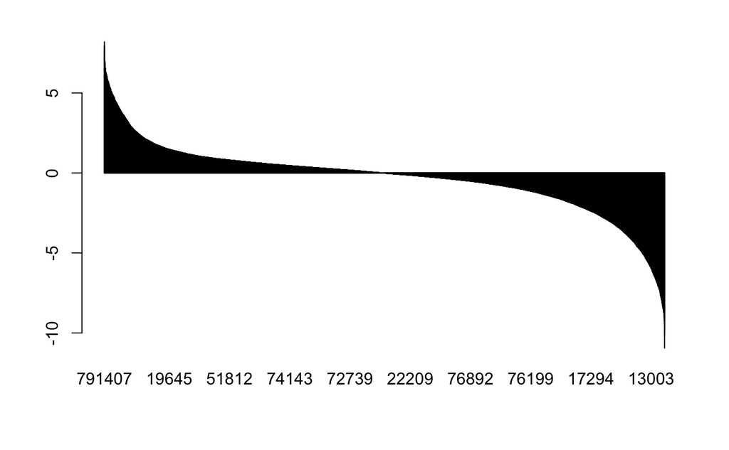

```r
#plot(ranks)
barplot(ranks)
```

Load pathways:

```r
load("data/mouse_H_v5.rdata")
pathways <- Mm.H
```

Conduct analysis:

```r
?fgsea
fgseaRes <- fgsea(pathways, ranks, minSize=15, maxSize = 500, nperm=1000)
class(fgseaRes)
```

```
[1] "data.table" "data.frame"
```

```r
dim(fgseaRes)
```

```
[1] 50  8
```

```r
#head(fgseaRes)
```

Glance at results:

```r
head(fgseaRes[order(padj), ])
```

```
                                      pathway        pval       padj         ES       NES nMoreExtreme size
1:                        HALLMARK_MYOGENESIS 0.001060445 0.01349892 -0.5405145 -1.759825            0  174
2:                   HALLMARK_APICAL_JUNCTION 0.001055966 0.01349892 -0.5280115 -1.721160            0  185
3: HALLMARK_EPITHELIAL_MESENCHYMAL_TRANSITION 0.001046025 0.01349892 -0.6879657 -2.249218            0  190
4:                    HALLMARK_UV_RESPONSE_DN 0.001079914 0.01349892 -0.5339268 -1.709396            0  141
5:                           HALLMARK_HYPOXIA 0.002092050 0.02092050 -0.4429099 -1.448038            1  190
6:                HALLMARK_HEDGEHOG_SIGNALING 0.004076087 0.03396739 -0.6112567 -1.609850            2   30
                                 leadingEdge
1:  17880,12373,22004,107589,14313,21345,...
2:   11468,98932,56191,12563,12821,68810,...
3:  11475,14264,16008,22004,98932,107589,...
4:   20583,16531,67252,15117,12064,12814,...
5:   16009,56277,12111,18654,13527,20198,...
6: 104001,12804,319504,21838,14766,11423,...
```

Plot outcome for the ‘HALLMARK_MYOGENESIS’ pathway:

First find rank of the ‘HALLMARK_MYOGENESIS’ pathway genes in the sorted genes:

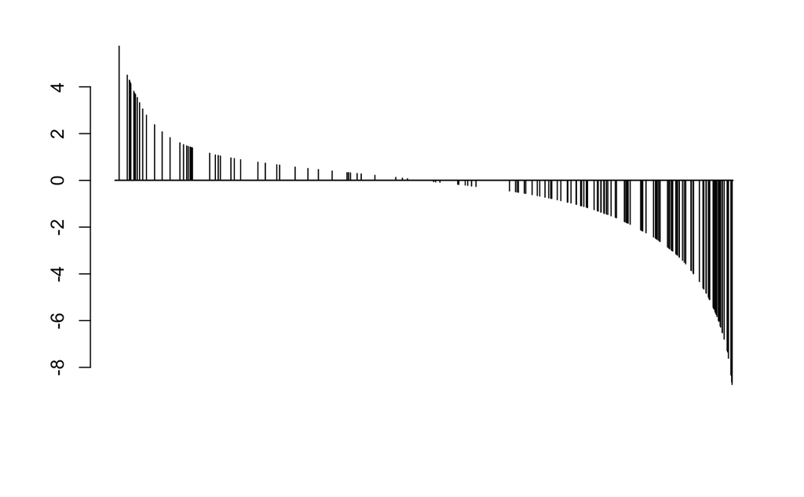

```r
# We will create a barplot of logFC for the sorted genes and add one vertical red bar for each gene in the 'HALLMARK_MYOGENESIS' pathway
#pathways[["HALLMARK_MYOGENESIS"]]
tmpInd <- match(pathways[["HALLMARK_MYOGENESIS"]],names(ranks))
tmpInd <- tmpInd[!is.na(tmpInd)]
#tmpInd
ranks2 <- rep(0,length(ranks))
ranks2[tmpInd] <- ranks[tmpInd]
barplot(ranks2)
```

Create enrichment score plot:

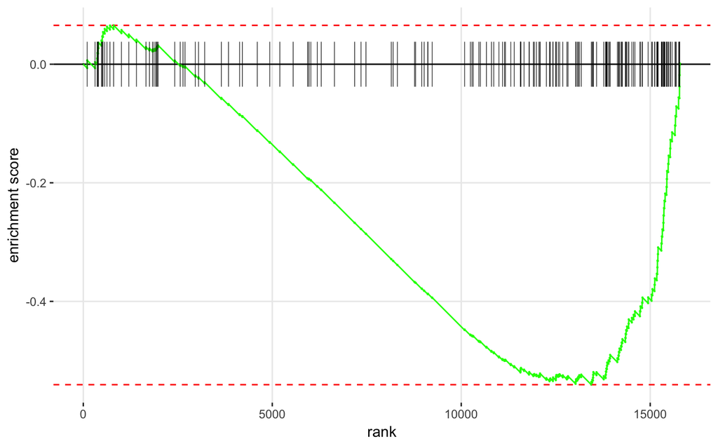

```r
plotEnrichment(pathways[["HALLMARK_MYOGENESIS"]],
               ranks)
```

Remember to check the [GSEA article](http://www.pnas.org/content/102/43/15545.full) for the complete explanation.

Select top pathways and plot outcome for all these:

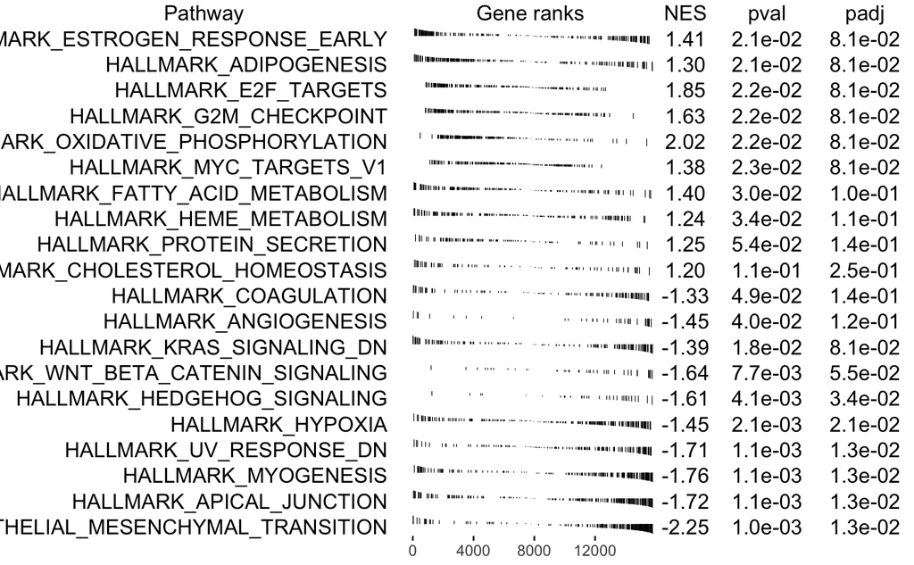

```r
pathwaysUp <- fgseaRes[ES > 0]
topPathwaysUp <- head( pathwaysUp$pathway[ order(pathwaysUp$pval) ], n=10 )
pathwaysDown <- fgseaRes[ES < 0]
topPathwaysDown <- head( pathwaysDown$pathway[ order( pathwaysDown$pval ) ], n=10 )
topPathways <- c(topPathwaysUp, rev(topPathwaysDown))
plotGseaTable(pathways[topPathways], ranks, fgseaRes, gseaParam = 0.5)
```

```r
?plotGseaTable
```

## Gene Set Testing - self-contained gene set tests

### ROAST gene set testing

[ROAST](https://academic.oup.com/bioinformatics/article-lookup/doi/10.1093/bioinformatics/btq401) is an example of a self-contained gene set test (Wu et al. 2010). It asks the question, “Do the genes in my set tend to be differentially expressed between my conditions of interest?”. ROAST does not use information on the other genes in the experiment, unlike `camera` (see below). ROAST is a good option for when you’re interested in a specific set, or a few sets. It is not really used to test thousands of sets at one time.

Here we will be using the C2 gene sets for mouse, available as .rdata files from the WEHI bioinformatics page http://bioinf.wehi.edu.au/software/MSigDB/index.html. The C2 gene sets contain 4725 curated gene sets collected from a variety of places: BioCarta, KEGG, Pathway Interaction Database, Reactome as well as some published studies. It doesn’t include GO terms.

```r
# Load in the mouse c2 gene sets
# The R object is called Mm.c2
load("data/mouse_c2_v5.rdata")
# Have a look at the first few gene sets
names(Mm.c2)[1:5]
```

```
[1] "KEGG_GLYCOLYSIS_GLUCONEOGENESIS"               "KEGG_CITRATE_CYCLE_TCA_CYCLE"
[3] "KEGG_PENTOSE_PHOSPHATE_PATHWAY"                "KEGG_PENTOSE_AND_GLUCURONATE_INTERCONVERSIONS"
[5] "KEGG_FRUCTOSE_AND_MANNOSE_METABOLISM"
```

```r
# Number of gene sets in C2
length(Mm.c2)
```

```
[1] 4725
```

The gene identifiers are Entrez Gene ID, as are the rownames of our DGEList object ‘dgeObj’. We need to map the Entrez gene ids between the list of gene sets and our DGEList object. We can do this using the `ids2indices` function.

```r
c2.ind <- ids2indices(Mm.c2, rownames(dgeObj$counts))
```

Let’s see if there are any MYC signalling pathways in MsigDB C2 collection. We can do this with the `grep` command on the names of the gene sets.

```r
grep("MYC_", names(c2.ind))
```

```
 [1]  496  544  621 1591 1592 1783 1784 2029 2030 2031 2032 2194 2195 2203 2204 2435 2436 2506 2507 2600 2609
[22] 2620 2621 2629 2676 2694 2706 2716 2727 2744 2786 2824 3311 3401 3817 3943 3944 4204 4205 4206 4207 4433
[43] 4434 4616
```

```r
# Let's save these so that we can subset c2.ind to test all gene sets with MYC in the name
myc <- grep("MYC_",names(c2.ind))
# What are these pathways called?
names(c2.ind)[myc]
```

```
 [1] "PID_MYC_ACTIV_PATHWAY"                           "PID_MYC_PATHWAY"
 [3] "PID_MYC_REPRESS_PATHWAY"                         "ODONNELL_TARGETS_OF_MYC_AND_TFRC_UP"
 [5] "ODONNELL_TARGETS_OF_MYC_AND_TFRC_DN"             "CAIRO_PML_TARGETS_BOUND_BY_MYC_UP"
 [7] "CAIRO_PML_TARGETS_BOUND_BY_MYC_DN"               "SCHLOSSER_MYC_AND_SERUM_RESPONSE_SYNERGY"
 [9] "SCHLOSSER_MYC_TARGETS_REPRESSED_BY_SERUM"        "SCHLOSSER_MYC_TARGETS_AND_SERUM_RESPONSE_DN"
[11] "SCHLOSSER_MYC_TARGETS_AND_SERUM_RESPONSE_UP"     "CEBALLOS_TARGETS_OF_TP53_AND_MYC_UP"
[13] "CEBALLOS_TARGETS_OF_TP53_AND_MYC_DN"             "KIM_MYC_AMPLIFICATION_TARGETS_UP"
[15] "KIM_MYC_AMPLIFICATION_TARGETS_DN"                "BENPORATH_MYC_TARGETS_WITH_EBOX"
[17] "BENPORATH_MYC_MAX_TARGETS"                       "MORI_EMU_MYC_LYMPHOMA_BY_ONSET_TIME_UP"
[19] "MORI_EMU_MYC_LYMPHOMA_BY_ONSET_TIME_DN"          "SCHUHMACHER_MYC_TARGETS_DN"
[21] "LEE_LIVER_CANCER_MYC_TGFA_DN"                    "LEE_LIVER_CANCER_MYC_UP"
[23] "MENSSEN_MYC_TARGETS"                             "LEE_LIVER_CANCER_MYC_TGFA_UP"
[25] "LEE_LIVER_CANCER_MYC_E2F1_DN"                    "LEE_LIVER_CANCER_MYC_E2F1_UP"
[27] "SCHUHMACHER_MYC_TARGETS_UP"                      "LEE_LIVER_CANCER_MYC_DN"
[29] "COLLER_MYC_TARGETS_UP"                           "COLLER_MYC_TARGETS_DN"
[31] "YU_MYC_TARGETS_UP"                               "YU_MYC_TARGETS_DN"
[33] "BILD_MYC_ONCOGENIC_SIGNATURE"                    "SANSOM_APC_MYC_TARGETS"
[35] "SOUCEK_MYC_TARGETS"                              "ELLWOOD_MYC_TARGETS_UP"
[37] "ELLWOOD_MYC_TARGETS_DN"                          "DANG_REGULATED_BY_MYC_UP"
[39] "DANG_REGULATED_BY_MYC_DN"                        "DANG_MYC_TARGETS_UP"
[41] "DANG_MYC_TARGETS_DN"                             "ACOSTA_PROLIFERATION_INDEPENDENT_MYC_TARGETS_UP"
[43] "ACOSTA_PROLIFERATION_INDEPENDENT_MYC_TARGETS_DN" "ALFANO_MYC_TARGETS"
```

Let’s use ROAST to see if these MYC related gene sets tend to be differentially expressed.

```r
# Specify a design matrix without an intercept term
design <- model.matrix(~ CellType + Status, data = sampleinfo)
# Run ROAST
myc.rst <- roast(dgeObj,
                 index=c2.ind[myc],
                 design=design,
                 contrast=3,
                 nrot=999)
myc.rst[1:15,]
```

```
                                            NGenes    PropDown     PropUp Direction PValue         FDR
BILD_MYC_ONCOGENIC_SIGNATURE                   187 0.016042781 0.11229947        Up  0.001 0.007333333
BENPORATH_MYC_TARGETS_WITH_EBOX                216 0.009259259 0.09259259        Up  0.001 0.007333333
ALFANO_MYC_TARGETS                             220 0.040909091 0.06818182        Up  0.001 0.007333333
PID_MYC_ACTIV_PATHWAY                           79 0.000000000 0.13924051        Up  0.002 0.013200000
MORI_EMU_MYC_LYMPHOMA_BY_ONSET_TIME_DN          16 0.062500000 0.06250000      Down  0.002 0.013200000
SCHLOSSER_MYC_TARGETS_AND_SERUM_RESPONSE_UP     48 0.000000000 0.12500000        Up  0.004 0.025666667
PID_MYC_REPRESS_PATHWAY                         59 0.033898305 0.06779661        Up  0.006 0.030250000
PID_MYC_PATHWAY                                 25 0.000000000 0.04000000        Up  0.006 0.030250000
SCHLOSSER_MYC_AND_SERUM_RESPONSE_SYNERGY        32 0.000000000 0.09375000        Up  0.007 0.031777778
LEE_LIVER_CANCER_MYC_E2F1_UP                    54 0.000000000 0.09259259        Up  0.009 0.037400000
CAIRO_PML_TARGETS_BOUND_BY_MYC_UP               24 0.000000000 0.20833333        Up  0.010 0.038000000
SCHLOSSER_MYC_TARGETS_AND_SERUM_RESPONSE_DN     48 0.000000000 0.12500000        Up  0.011 0.038500000
DANG_MYC_TARGETS_UP                            144 0.006944444 0.09722222        Up  0.014 0.045692308
DANG_MYC_TARGETS_DN                             30 0.000000000 0.13333333        Up  0.016 0.048714286
SCHLOSSER_MYC_TARGETS_REPRESSED_BY_SERUM       156 0.012820513 0.04487179        Up  0.024 0.068933333
                                            PValue.Mixed   FDR.Mixed
BILD_MYC_ONCOGENIC_SIGNATURE                       0.002 0.007333333
BENPORATH_MYC_TARGETS_WITH_EBOX                    0.008 0.022000000
ALFANO_MYC_TARGETS                                 0.011 0.027176471
PID_MYC_ACTIV_PATHWAY                              0.006 0.018615385
MORI_EMU_MYC_LYMPHOMA_BY_ONSET_TIME_DN             0.042 0.058903226
SCHLOSSER_MYC_TARGETS_AND_SERUM_RESPONSE_UP        0.002 0.007333333
PID_MYC_REPRESS_PATHWAY                            0.019 0.038761905
PID_MYC_PATHWAY                                    0.001 0.003666667
SCHLOSSER_MYC_AND_SERUM_RESPONSE_SYNERGY           0.056 0.064263158
LEE_LIVER_CANCER_MYC_E2F1_UP                       0.045 0.059333333
CAIRO_PML_TARGETS_BOUND_BY_MYC_UP                  0.083 0.090750000
SCHLOSSER_MYC_TARGETS_AND_SERUM_RESPONSE_DN        0.001 0.003666667
DANG_MYC_TARGETS_UP                                0.002 0.007333333
DANG_MYC_TARGETS_DN                                0.007 0.020428571
SCHLOSSER_MYC_TARGETS_REPRESSED_BY_SERUM           0.001 0.003666667
```

Each row corresponds to a single gene set.

The NGenes column gives the number of genes in each set.

The PropDown and PropUp columns contain the proportions of genes in the set that are down- and up-regulated, respectively, with absolute fold changes greater than 2.

The net direction of change is determined from the significance of changes in each direction, and is shown in the Direction column.

The PValue provides evidence for whether the majority of genes in the set are DE in the specified direction

The PValue.Mixed provides evidence for whether the majority of genes in the set are DE in any direction.

FDRs are computed from the corresponding p-values across all sets.

## Challenge 1

> 1. Test whether the MYC signalling pathways tend to be differentially expressed between basal virgin vs lactating.
> 2. Look for gene sets containing “WNT” in the name and see whether they tend to be differentially expressed in basal pregnant vs lactating.

Notes

References

# Supplementary Material - CAMERA

### CAMERA gene set testing using the Broad’s curated gene sets

Other databases of gene sets that are available come from the Broad Institute’s Molecular Signatures Database ([MSigDB](http://software.broadinstitute.org/gsea/msigdb)). [CAMERA](https://academic.oup.com/nar/article/40/17/e133/2411151/Camera-a-competitive-gene-set-test-accounting-for) is good option for testing a very large number of gene sets such as the MSigDB sets, as it is very fast. It has the advantage of accounting for inter-gene correlation within each gene set (Wu and Smyth 2012).

CAMERA takes as input the DGEList object `dgeObj`, the indexed list of gene sets `c2.ind`, the design matrix, the contrast being tested, as well as some other arguments. By default, CAMERA can estimate the correlation for each gene set separately. However, in practise, it works well to set a small inter-gene correlation of about 0.05 using the `inter.gene.cor` argument.

```r
# Specify a design matrix without an intercept term
design <- model.matrix(~ CellType + Status, data = sampleinfo)
#design
# Check contrasts:
print(colnames(design))
```

```
[1] "(Intercept)"     "CellTypeluminal" "Statuspregnant"  "Statusvirgin"
```

```r
# Run analysis:
gst.camera <- camera.DGEList(dgeObj,index=c2.ind,design=design,contrast=2,inter.gene.cor=0.05)
```

CAMERA outputs a dataframe of the resulting statistics, with each row denoting a different gene set. The output is ordered by p-value so that the most significant should be at the top. Let’s look at the top 5 gene sets:

```r
gst.camera[1:5,]
```

```
                                                 NGenes Direction       PValue          FDR
LIM_MAMMARY_STEM_CELL_UP                            485      Down 1.798497e-10 8.492501e-07
LIM_MAMMARY_STEM_CELL_DN                            426        Up 3.272364e-08 7.726051e-05
LIM_MAMMARY_LUMINAL_PROGENITOR_UP                    57        Up 3.170860e-06 4.990933e-03
REACTOME_NCAM1_INTERACTIONS                          34      Down 4.685605e-06 5.531357e-03
PAPASPYRIDONOS_UNSTABLE_ATEROSCLEROTIC_PLAQUE_DN     43      Down 8.550376e-06 8.074975e-03
```

The total number of significant gene sets at 5% FDR is:

```r
table(gst.camera$FDR < 0.05)
```

```
FALSE  TRUE
 4699    23
```

You can write out the camera results to a csv file to open in excel.

```r
write.csv(gst.camera,file="gst_LumVsBas.csv")
```

## Challenge 2

> 1. Run `camera` on the pregnant vs lactating contrast.
> 2. Run `camera` on a different set of MSigDB gene sets, the hallmark datasets, `mouse_H_v5.rdata`. You will need to load in the hallmark gene sets, and the object will be called `Mm.H` in R.

Lun, Aaron T L, Yunshun Chen, and Gordon K Smyth. 2016. “It’s DE-licious: A Recipe for Differential Expression Analyses of RNA-seq Experiments Using Quasi-Likelihood Methods in edgeR.” *Methods in Molecular Biology (Clifton, N.J.)* 1418 (January): 391–416. doi:10.1007/978-1-4939-3578-9\_19.

Wu, D, and G K Smyth. 2012. “Camera: a competitive gene set test accounting for inter-gene correlation.” *Nucleic Acids Research* 40 (17). Oxford University Press: e133—–e133.

Wu, D, E Lim, F Vaillant, M L Asselin-Labat, J E Visvader, and G K Smyth. 2010. “ROAST: rotation gene set tests for complex microarray experiments.” *Bioinformatics* 26 (17). Oxford Univ Press: 2176–82.